# Matrix Algebra in R

Author

Published

February 14, 2024

Review the following tutorial on basic matrix algebra in R and complete the exercises at the bottom. Your solutions should include both R code and any output requested. You may organize your solutions using an R Markdown document or in a pdf/docx format.

You may collaborate with your classmates and consult external resources, but you should write and submit your own answer. **Any classmates with whom you collaborate should be credited at the top of your submission. Similarly, if you consult any external references, you should cite them clearly and explicitly.**

# Preliminaries

If you have never used R or are a little rusty, consider reviewing the tutorial [here](https://github.com/matloff/fasteR#overview) or the textbook [here](https://r4ds.hadley.nz/whole-game).

# Vectors

In R, vectors are sets of elements of the same type. We can create vectors using the concatenation function `c()` or by using a function like `numeric()` or `double()` to create a vector of a specific type.

```r
x <- c(16, 3, 0, 7, -2) # values specified
print(x)
```

```
[1] 16  3  0  7 -2
```

```r
y <- numeric(5) # empty numeric vector of length 5.
print(y)
```

```
[1] 0 0 0 0 0
```

We index vectors using `[index]` after the vector name:

```r
x[3]
```

```
[1] 0
```

```r
x[4]
```

```
[1] 7
```

If we use a negative index, we return the vector with that element removed:

```r
x[-4]
```

```
[1] 16  3  0 -2
```

Note that atomic vectors can only have one type of data. So the following lines work:

```r
x <- c(1, 2, 3)
y <- c("a", "b", "c")
z <- c(T, F, T)
```

but when we try

```r
c(1, "b", 3)
```

```
[1] "1" "b" "3"
```

R will force the elements in our vector to be of the same type. This is a common source of bugs.

## Generating vectors

The notation `a:b` generates integers starting at `a` and ending at `b`.

```r
1:6
```

```
[1] 1 2 3 4 5 6
```

The `rep` function repeats values of the first argument.

```r
rep("Hello", times = 3)
```

```
[1] "Hello" "Hello" "Hello"
```

The `rnorm` function randomly generates `n` elements with the specified `mean` and `sd`.

```r
rnorm(n = 10, mean = 1, sd = 1)
```

```
 [1]  2.60409819  1.33158365  0.79439427  0.64043720  1.76425257 -0.94968076
 [7]  0.97017223  0.05758001  0.92285477  0.33038647
```

## Vector operations

Operations involving two vectors of the same length `x` and `y` are typically carried out element-wise:

```r
x <- 1:4
y <- 5:8
x + y # element-wise addition
```

```
[1]  6  8 10 12
```

```r
x * y # element-wise multiplication
```

```
[1]  5 12 21 32
```

Operations involving a vector and a scalar are typically carried out along the entire vector, recycling the scalar value.

```r
x <- 1:4
x + 2 # scalar addition
```

```
[1] 3 4 5 6
```

```r
x * 2 # scalar multiplication
```

```
[1] 2 4 6 8
```

The dot product can be carried out by using element-wise multiplication with the `sum()` function or the `%*%` operator

```r
x <- 1:4
y <- 5:8
sum(x * y)
```

```
[1] 70
```

```r
x %*% y
```

```
     [,1]
[1,]   70
```

## Useful functions for vectors

- `max()`, `min()`, `mean()`, `median()`, `sum()`, `sd()`, `var()`
- `length()` returns the number of elements in the vector
- `head()` and `tail()` return the beginning and end vectors
- `sort()` will sort
- `summary()` returns a 5-number summary
- `any()` and `all()` to check conditions on Boolean vectors
- `hist()` will return a crude histogram

# Matrices

**Matrices** are two-dimensional extensions of vectors: they have **rows** and **columns**. We can create a matrix using the function `matrix()`.

```r
x <- c(1, 2, 3, 4, 5)
y <- c(5, 4, 3, 2, 1)
my_matrix <- matrix(c(x, y), nrow = 2, ncol = 5, byrow = TRUE)
my_matrix
```

```
     [,1] [,2] [,3] [,4] [,5]
[1,]    1    2    3    4    5
[2,]    5    4    3    2    1
```

We can also generate matrices by column binding (`cbind()`) and row binding (`rbind()`) vectors:

```r
cbind(x, y)
```

```
     x y
[1,] 1 5
[2,] 2 4
[3,] 3 3
[4,] 4 2
[5,] 5 1
```

```r
rbind(x, y)
```

```
  [,1] [,2] [,3] [,4] [,5]
x    1    2    3    4    5
y    5    4    3    2    1
```

Indexing a matrix is similar to indexing a vector, except we must index both the row and column, in that order.

```r
my_matrix
```

```
     [,1] [,2] [,3] [,4] [,5]
[1,]    1    2    3    4    5
[2,]    5    4    3    2    1
```

```r
my_matrix[2, 3]
```

```
[1] 3
```

As with vectors, we can subset using a negative index.

```r
my_matrix
```

```
     [,1] [,2] [,3] [,4] [,5]
[1,]    1    2    3    4    5
[2,]    5    4    3    2    1
```

```r
my_matrix[-2, -4]
```

```
[1] 1 2 3 5
```

```r
# Note: Leaving an index blank includes all indices
my_matrix[, -c(1, 3, 4, 5)]
```

```
[1] 2 4
```

What happened here? When subsetting a matrix reduces one dimension to length 1, R automatically coerces it into a vector. We can prevent this by including `drop = FALSE`.

```r
my_matrix[, -c(1, 3, 4, 5)]
```

```
[1] 2 4
```

```r
is.matrix(my_matrix[, -c(1, 3, 4, 5)])
```

```
[1] FALSE
```

```r
my_matrix[, -c(1, 3, 4, 5), drop = FALSE]
```

```
     [,1]
[1,]    2
[2,]    4
```

We can also fill in an empty matrix using indices. In R, you should always start by initializing an empty matrix of the right size.

```r
my_results <- matrix(NA, nrow = 3, ncol = 3)
my_results
```

```
     [,1] [,2] [,3]
[1,]   NA   NA   NA
[2,]   NA   NA   NA
[3,]   NA   NA   NA
```

Then I can replace a single row (or column) using indices as follows.

```r
my_results[2, ] <- c(2, 4, 3)
my_results
```

```
     [,1] [,2] [,3]
[1,]   NA   NA   NA
[2,]    2    4    3
[3,]   NA   NA   NA
```

We can also fill in multiple rows (or columns) at once. (Likewise, we can also do subsets of rows/columns, or unique entries). Note that values are **recycled**:

```r
my_results[c(1, 3), ] <- 7
my_results
```

```
     [,1] [,2] [,3]
[1,]    7    7    7
[2,]    2    4    3
[3,]    7    7    7
```

Matrices, like vectors, can only have entries of one type.

```r
rbind(c(1, 2, 3), c("a", "b", "c"))
```

```
     [,1] [,2] [,3]
[1,] "1"  "2"  "3"
[2,] "a"  "b"  "c"
```

## Matrix operations

Let’s create 3 matrices for the purposes of demonstrating matrix functions.

```r
mat1 <- matrix(1:6, nrow = 2, ncol = 3, byrow = TRUE)
mat1
```

```
     [,1] [,2] [,3]
[1,]    1    2    3
[2,]    4    5    6
```

```r
mat2 <- matrix(1:6, nrow = 3, ncol = 2)
mat2
```

```
     [,1] [,2]
[1,]    1    4
[2,]    2    5
[3,]    3    6
```

```r
mat3 <- matrix(5:10, nrow = 2, ncol = 3, byrow = TRUE)
mat3
```

```
     [,1] [,2] [,3]
[1,]    5    6    7
[2,]    8    9   10
```

For matrices of the same dimensions, element-wise operations are available:

```r
mat1 + mat3 # element-wise addition
```

```
     [,1] [,2] [,3]
[1,]    6    8   10
[2,]   12   14   16
```

```r
mat1 * mat3 # element-wise multiplication
```

```
     [,1] [,2] [,3]
[1,]    5   12   21
[2,]   32   45   60
```

For matrix multiplication, we use the `%*%` operator:

```r
mat_square <- mat1 %*% mat2
mat_square
```

```
     [,1] [,2]
[1,]   14   32
[2,]   32   77
```

## Useful functions for matrices

#### Column Bind Matrices `cbind()`

```r
cbind(mat1, mat3)
```

```
     [,1] [,2] [,3] [,4] [,5] [,6]
[1,]    1    2    3    5    6    7
[2,]    4    5    6    8    9   10
```

#### Transpose `t()`

```r
t(mat1)
```

```
     [,1] [,2]
[1,]    1    4
[2,]    2    5
[3,]    3    6
```

#### Column Sums `colSums()`

```r
colSums(mat1)
```

```
[1] 5 7 9
```

#### Row Sums `rowSums()`

```r
rowSums(mat1)
```

```
[1]  6 15
```

#### Column Means `colMeans()`

```r
colMeans(mat1)
```

```
[1] 2.5 3.5 4.5
```

#### Row Means `rowMeans()`

```r
rowMeans(mat1)
```

```
[1] 2 5
```

#### Dimensions `dim()`

```r
dim(mat1)
```

```
[1] 2 3
```

#### Determinant `det()`

```r
det(mat_square)
```

```
[1] 54
```

#### Matrix Inverse `solve()`

```r
solve(mat_square)
```

```
           [,1]       [,2]
[1,]  1.4259259 -0.5925926
[2,] -0.5925926  0.2592593
```

#### Matrix Diagonal `diag()`

```r
diag(mat_square)
```

```
[1] 14 77
```

#### Matrix Trace `sum(diag())`

```r
sum(diag(mat_square))
```

```
[1] 91
```

# Eigenvalues

We can use the `eigen()` function to compute eigenvalues and eigenvectors of matrices.

```r
mat_asym <- matrix(c(1, 0, 2, 1), nrow = 2)
ev <- eigen(mat_asym)
ev$values # eigenvalues
```

```
[1] 1 1
```

```r
ev$vectors # eigenvectors
```

```
     [,1]          [,2]
[1,]    1 -1.000000e+00
[2,]    0  1.110223e-16
```

Note that eigenvalues and eigenvectors are calculated numerically, so tiny values (very close to zero) may show up in the eigenvectors. The `zapsmall()` function can be useful to replace these with zero. When a matrix is diagonalizable, the eigenvectors will be orthogonal.

```r
mat_asym <- matrix(c(1, 0, 2, 1), nrow = 2)
ev <- eigen(mat_asym)
ev$values # eigenvalues
```

```
[1] 1 1
```

```r
zapsmall(ev$vectors) # eigenvectors
```

```
     [,1] [,2]
[1,]    1   -1
[2,]    0    0
```

If your matrix is symmetric, you can specify this using `symmetric = TRUE`.

```r
ev <- eigen(mat_square, symmetric = TRUE)
ev$values # eigenvalues
```

```
[1] 90.4026725  0.5973275
```

```r
ev$vectors # eigenvectors
```

```
          [,1]       [,2]
[1,] 0.3863177 -0.9223658
[2,] 0.9223658  0.3863177
```

When a matrix is not diagonalizable, the eigenvectors will not be orthogonal.

```r
mat_asym <- matrix(c(0, 0, 1, 0), byrow = T, nrow = 2)
ev <- eigen(mat_asym)
ev$values # eigenvalues
```

```
[1] 0 0
```

```r
zapsmall(ev$vectors) # eigenvectors
```

```
     [,1] [,2]
[1,]    0    0
[2,]    1   -1
```

# Visualization

The `plot3D` package provides some basic tools for generating static 3D visualizations:

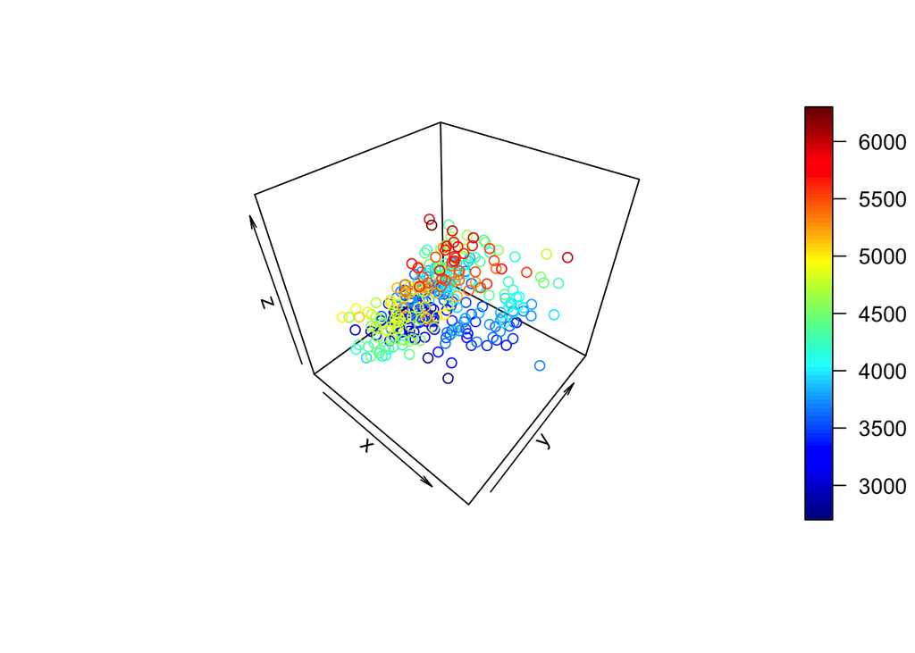

```r
library(palmerpenguins)
data(penguins)
library(plot3D)
scatter3D(x = penguins$bill_length_mm,
          y = penguins$bill_depth_mm,
          z = penguins$body_mass_g)
```

Note that 3D scatter plots are often difficult to read/interpret. You may often be able to get more effective results using a 2D plane and color as your third variable.

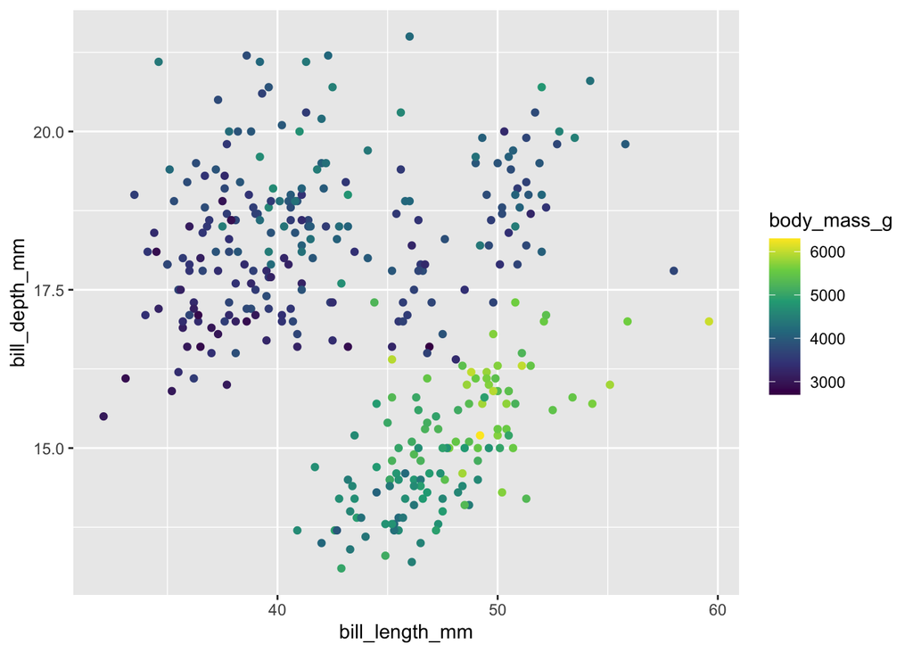

```r
library(ggplot2)
ggplot(penguins, aes(x = bill_length_mm, y = bill_depth_mm, color = body_mass_g)) +
  geom_point() +
  scale_color_viridis_c()
```

# Exercises

1. Create a vector `x` containing the integers 1 through 100 and compute the length of `x` by taking the square root of the dot product of `x` with itself.
2. Construct the following matrices in R and use matrix functions/operations to answer the following questions.

$$A=\begin{bmatrix}
1 & 2 & 3 & 4 \\
0 & 1 & 1 & 2 \\
1 & 3 & 4 & 6
\end{bmatrix}\hspace{2cm}
B=\begin{bmatrix}
1 & 1 & 2 \\
2 & 2 & 4 \\
5 & 6 & 7 \\
5 & 6 & 8
\end{bmatrix}$$

1. What is $AB$?
2. What is $B^T A^T$?
3. Is $AB$ invertible? If so, what is its inverse?
4. Is $A^T A$ invertible? If so, what is its inverse?
5. Is $B^T B$ invertible? If so, what is its inverse?
6. What are the non-zero eigenvalues of $A^T A$? How do they compare to the non-zero eigenvalues of $AA^T$?
3. Use matrix operations in R to solve the following system of linear equations:

$$\begin{align}
7x+2y+z&=30\\
8x+2y-z&=24\\
x+y+z&=12
\end{align}$$

4. Use a 3d scatter plot to visualize the relationships between the variables `mpg`, `hp`, and `wt` from the `mtcars` dataset (included in R).